# Scene Data Exploration

## Timelines

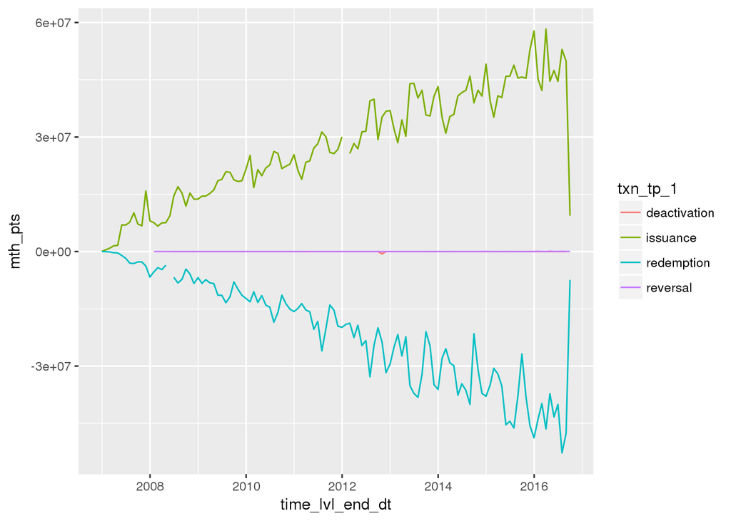

```r
group_by(scene_pt_fact, time_lvl_end_dt, txn_tp_1)%>%
  summarise(mth_pts = sum(as.numeric(pt, na.rm=TRUE)))%>%
  ggplot() + geom_line(aes(x=time_lvl_end_dt, y=mth_pts, group=txn_tp_1, colour=txn_tp_1))
```

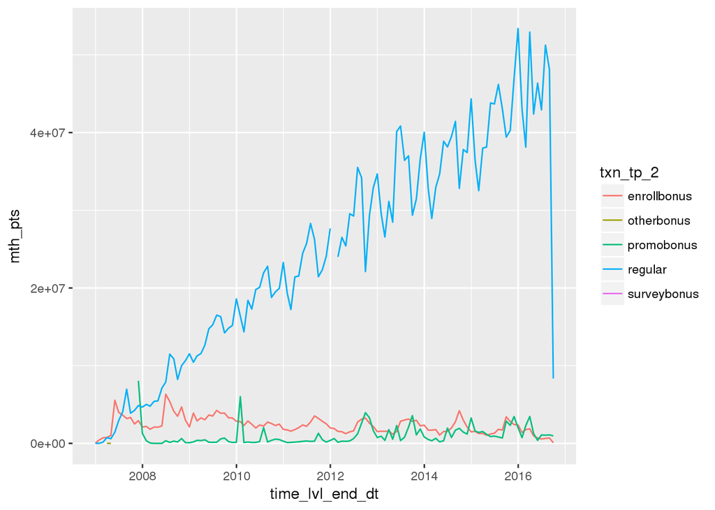

```r
group_by(scene_pt_fact, time_lvl_end_dt, txn_tp_2)%>%
  filter(txn_tp_1=="issuance")%>%
  summarise(mth_pts = sum(as.numeric(pt, na.rm=TRUE)))%>%
  ggplot() + geom_line(aes(x=time_lvl_end_dt, y=mth_pts, group=txn_tp_2, colour=txn_tp_2))
```

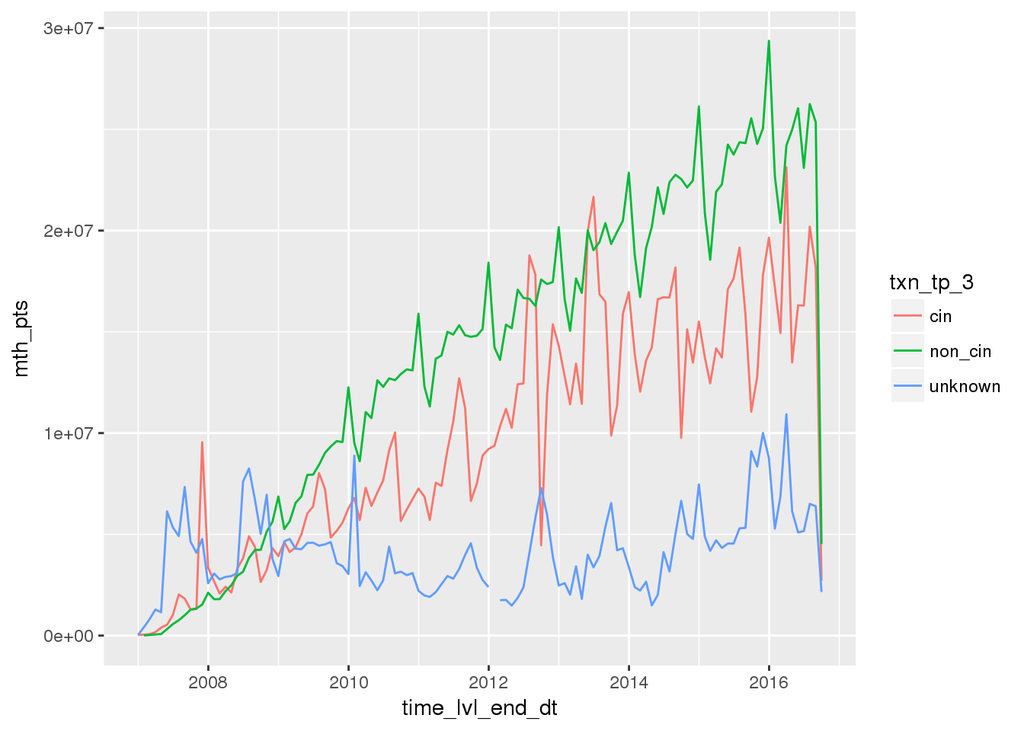

```r
group_by(scene_pt_fact, time_lvl_end_dt, txn_tp_3)%>%
  filter(txn_tp_1=="issuance")%>%
  summarise(mth_pts = sum(as.numeric(pt, na.rm=TRUE)))%>%
  ggplot() + geom_line(aes(x=time_lvl_end_dt, y=mth_pts, group=txn_tp_3, colour=txn_tp_3))
```

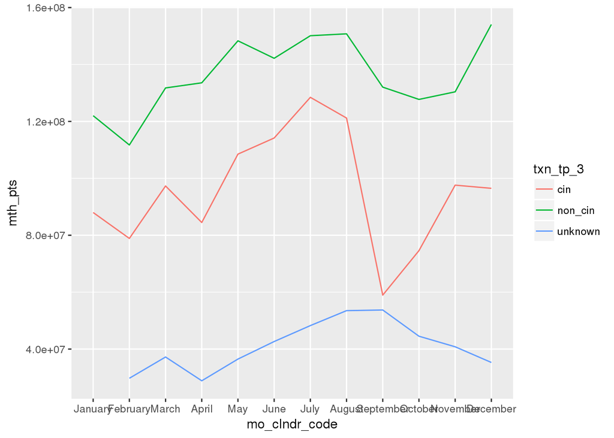

```r
scene_pt_fact$mo_clndr_code<-
  factor(scene_pt_fact$mo_clndr_code,levels=month.name, ordered=TRUE)

group_by(scene_pt_fact, mo_clndr_code, txn_tp_3)%>%
  filter(txn_tp_1=="issuance")%>%
  summarise(mth_pts = sum(as.numeric(pt, na.rm=TRUE)))%>%
  ggplot() + geom_line(aes(x=mo_clndr_code, y=mth_pts, group=txn_tp_3, colour=txn_tp_3))
```

A quick view at the aggregate month level, we see that cineplex pts issuane peaks in the summer, while non-cin points peaks in December as well.

# Table: scene_pt_tp_dim

This table provides descriptive information, such as point types, merchant names and transaction source, to transactions recorded in the ‘scene_pt_fact’ table.

This table does not provide much value by itself. It has already been joined to the ‘scene_pt_fact’ table, and thus will probably not be useful on its own.

```r
scene_pt_tp_dim <- read_csv(paste(in_path, 'scene_pt_tp_dim.csv', sep=""))
```

Here are the details of the table:

```r
dim(scene_pt_tp_dim)
```

```
## [1] 306   8
```

```r
colnames(scene_pt_tp_dim)
```

```
## [1] "scene_pt_tp_key" "cd"              "nm"              "desc"
## [5] "txn_src"         "txn_tp_1"        "txn_tp_2"        "txn_tp_3"
```

```r
str(scene_pt_tp_dim)
```

```
## Classes 'tbl_df', 'tbl' and 'data.frame':    306 obs. of  8 variables:
##  $ scene_pt_tp_key: int  -1 1 2 3 4 5 6 7 8 9 ...
##  $ cd             : chr  "UNKNOWN" "POSCIN09186" "EBNS" "CINEBNS" ...
##  $ nm             : chr  "Unknown" "POS IN GALAXY #9186" "Enrollment Bonus" "Cineplex Enrollment Bonus" ...
##  $ desc           : chr  "Unknown" "POS IN GALAXY #9186" "SCENE Enrollment Bonus" "Cineplex Employee Enrollment Bonus" ...
##  $ txn_src        : chr  "UNK" "BNS" "SCE" "SCE" ...
##  $ txn_tp_1       : chr  "issuance" "issuance" "issuance" "issuance" ...
##  $ txn_tp_2       : chr  "regular" "regular" "enrollbonus" "enrollbonus" ...
##  $ txn_tp_3       : chr  "unknown" "cin" "unknown" "cin" ...
##  - attr(*, "spec")=List of 2
##   ..$ cols   :List of 8
##   .. ..$ scene_pt_tp_key: list()
##   .. .. ..- attr(*, "class")= chr  "collector_integer" "collector"
##   .. ..$ cd             : list()
##   .. .. ..- attr(*, "class")= chr  "collector_character" "collector"
##   .. ..$ nm             : list()
##   .. .. ..- attr(*, "class")= chr  "collector_character" "collector"
##   .. ..$ desc           : list()
##   .. .. ..- attr(*, "class")= chr  "collector_character" "collector"
##   .. ..$ txn_src        : list()
##   .. .. ..- attr(*, "class")= chr  "collector_character" "collector"
##   .. ..$ txn_tp_1       : list()
##   .. .. ..- attr(*, "class")= chr  "collector_character" "collector"
##   .. ..$ txn_tp_2       : list()
##   .. .. ..- attr(*, "class")= chr  "collector_character" "collector"
##   .. ..$ txn_tp_3       : list()
##   .. .. ..- attr(*, "class")= chr  "collector_character" "collector"
##   ..$ default: list()
##   .. ..- attr(*, "class")= chr  "collector_guess" "collector"
##   ..- attr(*, "class")= chr "col_spec"
```

```r
summary(scene_pt_tp_dim)
```

```
##  scene_pt_tp_key         cd                 nm
##  Min.   :   -1.00   Length:306         Length:306
##  1st Qu.:   76.25   Class :character   Class :character
##  Median :  152.50   Mode  :character   Mode  :character
##  Mean   : 7873.25
##  3rd Qu.:14002.75
##  Max.   :51001.00
##      desc             txn_src            txn_tp_1
##  Length:306         Length:306         Length:306
##  Class :character   Class :character   Class :character
##  Mode  :character   Mode  :character   Mode  :character
##
##
##
##    txn_tp_2           txn_tp_3
##  Length:306         Length:306
##  Class :character   Class :character
##  Mode  :character   Mode  :character
##
##
##
```

Here are the first 20 rows of the data:

```r
head(scene_pt_tp_dim, n=20)
```

```
## # A tibble: 20 x 8
##    scene_pt_tp_key                    cd
##              <int>                 <chr>
##  1              -1               UNKNOWN
##  2               1           POSCIN09186
##  3               2                  EBNS
##  4               3               CINEBNS
##  5               4              CINISSUE
##  6               5             CINREDEEM
##  7               6                CNCADJ
##  8               7            CINREVERSE
##  9               8         BNSSURVEY2500
## 10               9         BNSSURVEY1000
## 11              10     SPRINGOFFER2007OP
## 12              11 SPRINGOFFER2007-itune
## 13              12           POSCIN03134
## 14              13           POSCIN03138
## 15              14           POSCIN03140
## 16              15                 SCEOP
## 17              16                 SCECD
## 18              17                   ALL
## 19              18                   POS
## 20              19           POSCINCINEP
## # ... with 6 more variables: nm <chr>, desc <chr>, txn_src <chr>,
## #   txn_tp_1 <chr>, txn_tp_2 <chr>, txn_tp_3 <chr>
```

# Table: iwd_time

This table lists dates and times. This table also does not provide much value by itself. It is mapped to the ‘scene_pt_fact’ table and provides time descriptions to the transactions recorded in that table.

```r
iwd_time <- read_csv(paste(in_path, 'iwd_time.csv', sep=""))
```

Here are the details of the table:

```r
dim(iwd_time)
```

```
## [1] 9657   20
```

```r
colnames(iwd_time)
```

```
##  [1] "time_key"         "time_lvl"         "time_seq_nbr"
##  [4] "time_yr_seq_nbr"  "time_crnt_f"      "anul_clndr_code"
##  [7] "anul_fncl_code"   "qtrly_clndr_code" "qtrly_fncl_code"
## [10] "mo_clndr_code"    "day_of_wk_code"   "day_of_wk_desc"
## [13] "day_dt"           "anul_fncl_key"    "qtrly_fncl_key"
## [16] "mo_fncl_key"      "day_fncl_key"     "time_desc"
## [19] "time_lvl_st_dt"   "time_lvl_end_dt"
```

```r
str(iwd_time)
```

```
## Classes 'tbl_df', 'tbl' and 'data.frame':    9657 obs. of  20 variables:
##  $ time_key        : int  5727 5728 5729 5730 5731 5732 5733 5734 5735 5736 ...
##  $ time_lvl        : chr  "Day" "Day" "Day" "Day" ...
##  $ time_seq_nbr    : int  5727 5728 5729 5730 5731 5732 5733 5734 5735 5736 ...
##  $ time_yr_seq_nbr : int  246 247 248 249 250 251 252 253 254 255 ...
##  $ time_crnt_f     : chr  "N" "N" "N" "N" ...
##  $ anul_clndr_code : int  1995 1995 1995 1995 1995 1995 1995 1995 1995 1995 ...
##  $ anul_fncl_code  : int  1995 1995 1995 1995 1995 1995 1995 1995 1995 1995 ...
##  $ qtrly_clndr_code: int  4 4 4 4 4 4 4 4 4 4 ...
##  $ qtrly_fncl_code : int  4 4 4 4 4 4 4 4 4 4 ...
##  $ mo_clndr_code   : chr  "October" "October" "October" "October" ...
##  $ day_of_wk_code  : int  1 2 3 4 5 6 7 1 2 3 ...
##  $ day_of_wk_desc  : chr  "Sunday" "Monday" "Tuesday" "Wednesday" ...
##  $ day_dt          : Date, format: "1995-10-01" "1995-10-02" ...
##  $ anul_fncl_key   : int  9915 9915 9915 9915 9915 9915 9915 9915 9915 9915 ...
##  $ qtrly_fncl_key  : int  9600 9600 9600 9600 9600 9600 9600 9600 9600 9600 ...
##  $ mo_fncl_key     : int  8779 8779 8779 8779 8779 8779 8779 8779 8779 8779 ...
##  $ day_fncl_key    : int  5727 5728 5729 5730 5731 5732 5733 5734 5735 5736 ...
##  $ time_desc       : chr  "10/01/1995 - Fiscal Q4/95" "10/02/1995 - Fiscal Q4/95" "10/03/1995 - Fiscal Q4/95" "10/04/1995 - Fiscal Q4/95" ...
##  $ time_lvl_st_dt  : Date, format: "1995-10-01" "1995-10-02" ...
##  $ time_lvl_end_dt : Date, format: "1995-10-01" "1995-10-02" ...
##  - attr(*, "spec")=List of 2
##   ..$ cols   :List of 20
##   .. ..$ time_key        : list()
##   .. .. ..- attr(*, "class")= chr  "collector_integer" "collector"
##   .. ..$ time_lvl        : list()
##   .. .. ..- attr(*, "class")= chr  "collector_character" "collector"
##   .. ..$ time_seq_nbr    : list()
##   .. .. ..- attr(*, "class")= chr  "collector_integer" "collector"
##   .. ..$ time_yr_seq_nbr : list()
##   .. .. ..- attr(*, "class")= chr  "collector_integer" "collector"
##   .. ..$ time_crnt_f     : list()
##   .. .. ..- attr(*, "class")= chr  "collector_character" "collector"
##   .. ..$ anul_clndr_code : list()
##   .. .. ..- attr(*, "class")= chr  "collector_integer" "collector"
##   .. ..$ anul_fncl_code  : list()
##   .. .. ..- attr(*, "class")= chr  "collector_integer" "collector"
##   .. ..$ qtrly_clndr_code: list()
##   .. .. ..- attr(*, "class")= chr  "collector_integer" "collector"
##   .. ..$ qtrly_fncl_code : list()
```

[output cut: 14 more lines]

```
##   .. ..$ mo_fncl_key     : list()
##   .. .. ..- attr(*, "class")= chr  "collector_integer" "collector"
##   .. ..$ day_fncl_key    : list()
##   .. .. ..- attr(*, "class")= chr  "collector_integer" "collector"
##   .. ..$ time_desc       : list()
##   .. .. ..- attr(*, "class")= chr  "collector_character" "collector"
##   .. ..$ time_lvl_st_dt  :List of 1
##   .. .. ..$ format: chr ""
##   .. .. ..- attr(*, "class")= chr  "collector_date" "collector"
##   .. ..$ time_lvl_end_dt :List of 1
##   .. .. ..$ format: chr ""
##   .. .. ..- attr(*, "class")= chr  "collector_date" "collector"
##   ..$ default: list()
##   .. ..- attr(*, "class")= chr  "collector_guess" "collector"
##   ..- attr(*, "class")= chr "col_spec"
```

```r
summary(iwd_time)
```

```
##     time_key       time_lvl          time_seq_nbr   time_yr_seq_nbr
##  Min.   : 5727   Length:9657        Min.   :   15   Min.   :   1
##  1st Qu.: 8141   Class :character   1st Qu.: 7708   1st Qu.:  81
##  Median :12576   Mode  :character   Median :12293   Median : 177
##  Mean   :12256                      Mean   :11708   Mean   : 182
##  3rd Qu.:15609                      3rd Qu.:15463   3rd Qu.: 273
##  Max.   :19118                      Max.   :18631   Max.   :2021
##
##  time_crnt_f        anul_clndr_code anul_fncl_code qtrly_clndr_code
##  Length:9657        Min.   :1994    Min.   :1994   Min.   :1.000
##  Class :character   1st Qu.:2002    1st Qu.:2002   1st Qu.:2.000
##  Mode  :character   Median :2008    Median :2008   Median :3.000
##                     Mean   :2008    Mean   :2008   Mean   :2.523
##                     3rd Qu.:2014    3rd Qu.:2014   3rd Qu.:4.000
##                     Max.   :2021    Max.   :2021   Max.   :4.000
##                                                    NA's   :28
##  qtrly_fncl_code mo_clndr_code      day_of_wk_code  day_of_wk_desc
##  Min.   :1.000   Length:9657        Min.   :1.000   Length:9657
##  1st Qu.:1.000   Class :character   1st Qu.:2.000   Class :character
##  Median :3.000   Mode  :character   Median :4.000   Mode  :character
##  Mean   :2.499                      Mean   :3.999
##  3rd Qu.:4.000                      3rd Qu.:6.000
##  Max.   :4.000                      Max.   :7.000
##  NA's   :28                         NA's   :433
##      day_dt           anul_fncl_key   qtrly_fncl_key   mo_fncl_key
##  Min.   :1995-10-01   Min.   : 9914   Min.   : 9600   Min.   : 8600
##  1st Qu.:2002-01-22   1st Qu.: 9922   1st Qu.: 9697   1st Qu.: 8803
##  Median :2008-05-16   Median :12878   Median :12557   Median :12596
##  Mean   :2008-05-16   Mean   :13265   Mean   :12936   Mean   :12723
##  3rd Qu.:2014-09-08   3rd Qu.:15758   3rd Qu.:15557   3rd Qu.:15636
##  Max.   :2020-12-31   Max.   :19118   Max.   :18557   Max.   :18636
##  NA's   :433                          NA's   :28      NA's   :130
##   day_fncl_key    time_desc         time_lvl_st_dt
##  Min.   : 5727   Length:9657        Min.   :1993-11-01
##  1st Qu.: 8033   Class :character   1st Qu.:2002-01-20
##  Median :12576   Mode  :character   Median :2008-05-14
##  Mean   :12230                      Mean   :2008-05-14
##  3rd Qu.:15608                      3rd Qu.:2014-09-07
##  Max.   :18631                      Max.   :2020-12-31
##  NA's   :433
##  time_lvl_end_dt
##  Min.   :1994-10-31
##  1st Qu.:2002-01-23
##  Median :2008-05-17
##  Mean   :2008-05-17
##  3rd Qu.:2014-09-10
##  Max.   :2021-10-31
##
```

Here are the first 20 rows of the data:

```r
head(iwd_time, n=20)
```

```
## # A tibble: 20 x 20
##    time_key time_lvl time_seq_nbr time_yr_seq_nbr time_crnt_f
##       <int>    <chr>        <int>           <int>       <chr>
##  1     5727      Day         5727             246           N
##  2     5728      Day         5728             247           N
##  3     5729      Day         5729             248           N
##  4     5730      Day         5730             249           N
##  5     5731      Day         5731             250           N
##  6     5732      Day         5732             251           N
##  7     5733      Day         5733             252           N
##  8     5734      Day         5734             253           N
##  9     5735      Day         5735             254           N
## 10     5736      Day         5736             255           N
## 11     5737      Day         5737             256           N
## 12     5738      Day         5738             257           N
## 13     5739      Day         5739             258           N
## 14     5740      Day         5740             259           N
## 15     5741      Day         5741             260           N
## 16     5742      Day         5742             261           N
## 17     5743      Day         5743             262           N
## 18     5744      Day         5744             263           N
## 19     5745      Day         5745             264           N
## 20     5746      Day         5746             265           N
## # ... with 15 more variables: anul_clndr_code <int>, anul_fncl_code <int>,
## #   qtrly_clndr_code <int>, qtrly_fncl_code <int>, mo_clndr_code <chr>,
## #   day_of_wk_code <int>, day_of_wk_desc <chr>, day_dt <date>,
## #   anul_fncl_key <int>, qtrly_fncl_key <int>, mo_fncl_key <int>,
## #   day_fncl_key <int>, time_desc <chr>, time_lvl_st_dt <date>,
## #   time_lvl_end_dt <date>
```

## time level (time_lvl)

```r
summary(as.factor(iwd_time$time_lvl))
```

```
##     Day   Month Quarter    Year
##    9224     303     102      28
```

This field categorizes time_key into 4 levels: Day, Month, Quarter, Year

## month (mo_clndr_code)

This is the name of the calendar month.

```r
summary(as.factor(iwd_time$mo_clndr_code))
```

```
##     April    August  December  February   January      July      June
##       775       800       832       732       800       800       775
##     March       May  November      null   October September
##       800       800       806       130       832       775
```

NOTE: * The scene_pt_fact table gives us time keys at the month level. So, for purpose of analysing point transactions, we only need to map the ‘mo_clndr_code’ field to the scene_pt_fact table. ‘time_lvl’ field can be used to select “Month” level keys only. * Although other fields from this table cannot be linked to point transactions, the following fields from the ‘iwd_time’ table provides some interesting facts.

## anul_clndr_code

This indicates the calendar year of the corresponding time key.

```r
summary(iwd_time$anul_clndr_code)
```

```
##    Min. 1st Qu.  Median    Mean 3rd Qu.    Max.
##    1994    2002    2008    2008    2014    2021
```

earliest calendar year stamp: 1994, latest calendar year stamp: 2021

## anual_fncl_code

This indicates the bank’s fiscal year of the corresponding time key.

```r
summary(iwd_time$anul_fncl_code)
```

```
##    Min. 1st Qu.  Median    Mean 3rd Qu.    Max.
##    1994    2002    2008    2008    2014    2021
```

earliest fiscal year stamp: 1994, latest fiscal year stamp: 2021

Check if calendar year always equal fiscal year, Returned False.

```r
all(iwd_time$anul_clndr_code == iwd_time$anul_fncl_code)
```

```
## [1] FALSE
```

```r
iwd_time %>%
  filter(anul_clndr_code != anul_fncl_code) %>%
  select(mo_clndr_code) %>%
  group_by(mo_clndr_code) %>%
  count(mo_clndr_code)
```

```
## # A tibble: 3 x 2
##   mo_clndr_code     n
##           <chr> <int>
## 1      December   832
## 2      November   806
## 3          null    26
```

Looking at the month where calendar year differs from fiscal year, November seems to be the start of fiscal year at Scotiabank.

## qtrly_clndr_code

This field indicates the calendar quarter of the corresponding time_key.

```r
summary(as.factor(iwd_time$qtrly_clndr_code))
```

```
##    1    2    3    4 NA's
## 2357 2375 2401 2496   28
```

```r
iwd_time %>%
  filter(qtrly_clndr_code == "null") %>%
  select(time_lvl) %>%
  group_by(time_lvl) %>%
  count(time_lvl)
```

```
## # A tibble: 0 x 2
## # ... with 2 variables: time_lvl <chr>, n <int>
```

## qtrly_fncl_code

This field indicates the fiscal quarter of the corresponding time_key.

```r
summary(as.factor(iwd_time$qtrly_fncl_code))
```

```
##    1    2    3    4 NA's
## 2464 2332 2400 2433   28
```

```r
iwd_time %>%
  filter(qtrly_fncl_code == "null") %>%
  select(time_lvl) %>%
  group_by(time_lvl) %>%
  count(time_lvl)
```

```
## # A tibble: 0 x 2
## # ... with 2 variables: time_lvl <chr>, n <int>
```

```r
iwd_time%>%
  filter(!time_lvl %in% c("Year", "Quarter") ) %>%
  select(qtrly_fncl_code, mo_clndr_code) %>%
  distinct(qtrly_fncl_code, mo_clndr_code)
```

```
## # A tibble: 12 x 2
##    qtrly_fncl_code mo_clndr_code
##              <int>         <chr>
##  1               4       October
##  2               1      November
##  3               1      December
##  4               1       January
##  5               2      February
##  6               2         March
##  7               2         April
##  8               3           May
##  9               3          June
## 10               3          July
## 11               4        August
## 12               4     September
```

fiscal qtr 1: Nov-Jan, fiscal qtr 2: Feb-Apr, fiscal qtr 3: May-Jul, fiscal qtr 4: Aug-Oct